# S&P500 Pleasures

S&P Return histograms, after an idea from Drew Thornton and Joy Division’s famous “Unknown Pleasures” album cover, which has something to do with pulsar star frequencies, I think.

[figure not shown]

Unknown Pleasures by Joy Division - 1979

```r
#-------------------- Setup ----------------
library(dplyr)
library(ggplot2)
library(ggridges) #superceeds ggjoy
library(tidyverse)
library(lubridate)
library(Rblpapi)
library(stringr)
library(magick)
```

Insert the helper function to get Bloomberg data

```r
# ignore or delete this chunk if loading prefetched csv file.
#--------------------tidy_bdh--------------
# Get BBG Data
# CAUTION: The order of the returned secs series may not be the same as order of the secs inputs
# CAUTION: There is no guarantee that the all securities will have values for the same dates.
tidy_bdh<-function(secs,...){
  blpConnect() #must have a valid blp session running
  blp_bdh  <-bdh(secs,...=...)
  blp_bdh_tq<-bind_rows(blp_bdh,.id='ticker') %>%
    mutate(sector=word(ticker,-1)) %>%
    mutate(ticker=word(ticker,1)) %>%
    select(date,ticker,everything())%>%
    group_by(sector,ticker)
  #special case of one ticker
  if (length(secs)==1){
    blp_bdh_tq$ticker=word(secs,1)
    blp_bdh_tq$sector=word(secs,-1)
  }
  return(blp_bdh_tq)
}
# example
#fields=c('DAY_TO_DAY_TOT_RETURN_GROSS_DVDS',"LAST_PRICE",'FUND_TOTAL_ASSETS')
#START_DATE=as.Date("2002-03-31")
#secs = c(' OIGAX Equity','DODFX Equity')
#BDH_OPTIONS = c("periodicitySelection"="MONTHLY")
#
#bbg_ret_data  <-tidy_bdh(secs,
#                         fields=fields,
#                         start.date = START_DATE,
#                         end.date=Sys.Date(),
#                         options=BDH_OPTIONS)
```

```r
#------------- mutate_cond -------------------------
mutate_cond <- function(.data, condition, ..., envir = parent.frame()) {
  condition <- eval(substitute(condition), .data, envir)
  condition[is.na(condition)] = FALSE
  .data[condition, ] <- .data[condition, ] %>% mutate(...)
  .data
}
# --------
```

Fetch S&P 500 index data from Bloomberg

```r
# ignore or delete this chunk if loading prefetched csv file.
blpConnect()
secs=c("SPTR Index","SPX Index")
fields=c("LAST_PRICE")
START_DATE=as.Date("1970-01-01") #whatever.  as far back as possible
BDH_OPTIONS = c("periodicitySelection"="MONTHLY")
bbg_ret_data  <-tidy_bdh(secs,
                         fields=fields,
                         start.date = START_DATE,
                         end.date=Sys.Date(),
                         options=BDH_OPTIONS)
#save it
write_csv(bbg_ret_data,path='spx_returns.csv')
```

```r
#if you don't have bbg then use the csv file that came with this notebook
bbg_ret_data<-read_csv(file='spx_returns.csv')
```

```r
joy <- bbg_ret_data %>%
  filter(ticker=="SPX") %>%
  mutate(return=LAST_PRICE/lag(LAST_PRICE)-1) %>%
  na.omit() %>%
  mutate(year=as.factor(year(date))) %>%
  mutate(month=month(date)) %>%
  #rebase to a constant date
  mutate(doy=as.Date("1970-01-01")+ (date-make_date(year(date),1,1))) %>%
  group_by(year) %>%
  mutate(cumret=cumprod(1+return)-1)
#add full year return to each month
year_rank<-joy %>%
  top_n(1,date) %>%
  select(year,year_ret=cumret)
joy_low<-year_rank %>%
  ungroup() %>%
  filter(year_ret<0) %>%
  mutate(year_decile=ntile(year_ret,5))
joy_high<-year_rank %>%
  ungroup() %>%
  filter(year_ret>0) %>%
  mutate(year_decile=ntile( year_ret,5)+5)
year_rank<-bind_rows(joy_low,joy_high) %>%
    mutate(year_decile=as.factor(year_decile)) %>%
    group_by(year)
rm(joy_high,joy_low)
joy<- year_rank %>%
  left_join(joy) %>%
  ungroup()
#By default our plots will be in chronological order. If you'd like the ridge lines to appear
# in return order do this.
#order the year factor levels by average return for plotting
joy$year<-factor(joy$year,levels=unique(joy$year[order(joy$year_ret)]))
#regroup
joy<-joy %>% group_by(year)
```

Now let’s plot the density histograms of returns by year.

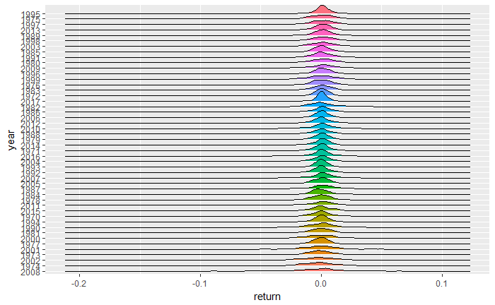

```r
# trivially simple with the ggridges package
gg<-ggplot(joy,aes(x=return,y=year,fill=year))
gg<-gg+geom_density_ridges()+guides(fill=FALSE)
gg
```

Cool! Now let’s make it more Joy Division-y.

[figure not shown]

```r
gg<-ggplot(joy,aes(x=return,y=year))
gg<- gg+geom_density_ridges(color = "#F0F0F0", fill = "black",scale=10)
gg<-gg+ scale_x_continuous(limits = c(-0.05,0.05))
gg<- gg+  theme(panel.grid = element_blank(),
          panel.background = element_rect(fill = "#000000"),
          axis.text = element_blank(),
          axis.ticks = element_blank(),
          axis.title = element_blank())
gg
```

Very nice.

Drew was also looking at cumulative returns rather than density. How would that work? Not well.

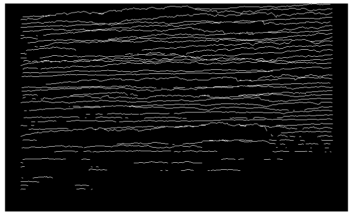

```r
gg<-ggplot(joy,aes(x=doy,y=year,height=cumret))
gg<- gg+geom_ridgeline(color = "#F0F0F0", fill = "black",scale=10)
gg<- gg+  theme(panel.grid = element_blank(),
          panel.background = element_rect(fill = "#000000"),
          axis.text = element_blank(),
          axis.ticks = element_blank(),
          axis.title = element_blank())
gg
```

While we might abandon our Joy Division stuff can we present cumulative returns in an attractive way?

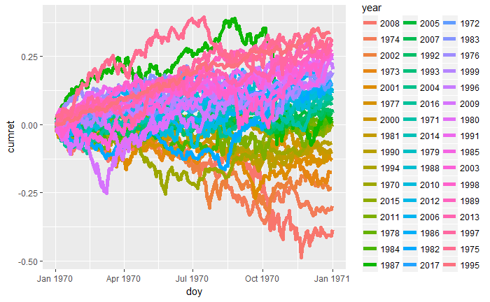

```r
gg<-ggplot(joy,aes(x=doy,y=cumret,color=year))+geom_line(size=2)
#gg<-gg+ scale_x_continuous(scales::)
gg
```

Yuck.

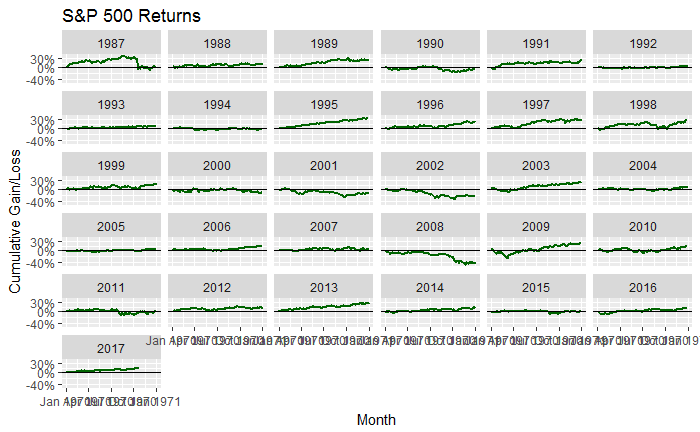

```r
#undo sort year by return
joy$year<-as.factor(as.numeric(as.character(joy$year)))
gg<- joy %>% filter(year(date)>1986) %>%
  ggplot(aes(x=doy,y=cumret))+geom_line(size=1,color="darkgreen")+facet_wrap(facets=~year)
gg<-gg + geom_hline(yintercept = 0)
#gg<-gg + scale_x_continuous(breaks=c(2,4,6,8,10,12))
gg<-gg + scale_y_continuous(labels = scales::percent,
                            breaks=c(-.40,.0,.30))
gg<-gg + labs(y="Cumulative Gain/Loss",x="Month",title="S&P 500 Returns")
gg
```

I think this at least gets the point across, even if it won’t get on an album cover.

Let’s try to duplicate what Drew ultimately got to. First do return distibution density plots

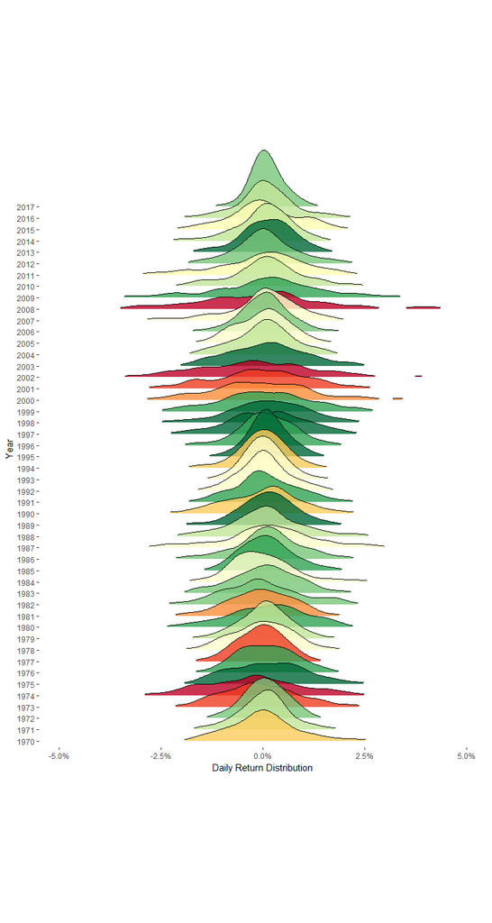

```r
#cook up a palette based on range of returns
color_good<-(RColorBrewer::brewer.pal(5,"YlGn"))
color_bad<-rev(RColorBrewer::brewer.pal(5,"YlOrRd"))
#color_set<-RColorBrewer::brewer.pal(10,"RdYlGn")
color_set<-c(color_bad,color_good)
#display palette
#image(1:10,1,as.matrix(1:10),col=color_set,xlab="",ylab="",xaxt="n",yaxt="n",bty="n")
gg<-ggplot(joy,aes(x=return,y=year,fill=year_decile))
gg<-gg+geom_density_ridges(rel_min_height=0.03,scale=5)
#gg<-gg+theme_ridges(font_size = 8)
gg<-gg+guides(fill=FALSE)+scale_x_continuous(labels=scales::percent,
                                             limits = c(-0.05,0.05))
gg<-gg+scale_fill_manual(values = alpha(color_set, .8))
gg<- gg+  theme(panel.grid = element_blank(),
                panel.grid.major.y = element_blank(),
                panel.background = element_rect(fill = "white"),
                aspect.ratio = 4/3)
gg<-gg+labs(x='Daily Return Distribution',y='Year')
gg
```

[figure not shown]

```r
image_display(animation)
```

[output not shown]

[output not shown]